# Tools Comparison (Simple): OpenCode + Opus 4.6

## Run Metadata

- Harness: `opencode`
- Model: `opus-4-6`
- Prompt type: `simple`

## Setup

```r
library(MASS)
library(dplyr)
library(ggplot2)
library(tidyr)
library(broom)
library(scales)
library(patchwork)
library(knitr)
library(kableExtra)

df <- readr::read_csv(here::here("data/synthetic/simulated_maternal_health_data.csv"))
```

## Prompt

```
Study this data set (`data/synthetic/simulated_maternal_health_data.csv`), show me descriptive statistics, pick a modeling strategy, and report the model. Be thorough.
```

## Analysis

### Data Overview

```r
tibble(
  Metric = c("Rows", "Columns", "Missing cells"),
  Value = c(
    format(nrow(df), big.mark = ","),
    ncol(df),
    sum(is.na(df))
  )
) |>
  kable(align = "lr") |>
  kable_styling(bootstrap_options = "striped", full_width = FALSE)
```

| Metric | Value |
| --- | --- |
| Rows | 50,000 |
| Columns | 20 |
| Missing cells | 0 |

```r
glimpse(df)
```

```
Rows: 50,000
Columns: 20
$ id                                    <dbl> 1, 2, 3, 4, 5, 6, 7, 8, 9, 10, 1…
$ provider_id                           <dbl> 1, 1, 1, 1, 1, 1, 1, 1, 1, 1, 1,…
$ state                                 <chr> "AK", "AK", "AK", "AK", "AK", "A…
$ received_comprehensive_postnatal_care <dbl> 0, 1, 0, 0, 0, 1, 1, 1, 0, 0, 0,…
$ self_report_income                    <chr> "$50,000–$74,999", "$50,000–$74,…
$ age                                   <dbl> 31, 26, 33, 37, 21, 33, 25, 34, …
$ edu                                   <chr> "hs", "hs", "some_college", "hs"…
$ race_ethnicity                        <chr> "white", "white", "white", "asia…
$ insurance                             <chr> "no_insurance", "no_insurance", …
$ job_type                              <chr> "unskilled", "unskilled", "unski…
$ dependents                            <dbl> 2, 2, 2, 2, 2, 2, 2, 3, 3, 3, 3,…
$ distance_to_provider                  <dbl> 1.7889754, 10.8991396, 35.122047…
$ obesity                               <dbl> 0, 0, 1, 0, 1, 1, 1, 1, 1, 1, 0,…
$ multiple_gestation                    <dbl> 0, 0, 0, 0, 0, 1, 0, 1, 0, 0, 0,…
$ diabetes                              <dbl> 0, 0, 0, 0, 0, 0, 0, 0, 0, 0, 0,…
$ heart_disease                         <dbl> 0, 0, 0, 1, 0, 0, 1, 0, 0, 0, 0,…
$ placenta_previa                       <dbl> 0, 0, 0, 0, 0, 0, 0, 0, 0, 0, 0,…
$ hypertension                          <dbl> 0, 0, 1, 0, 0, 1, 0, 0, 0, 0, 0,…
$ gest_hypertension                     <dbl> 0, 0, 0, 0, 0, 0, 0, 0, 0, 0, 0,…
$ preeclampsia                          <dbl> 0, 0, 0, 0, 0, 0, 0, 0, 0, 0, 0,…
```

The dataset contains maternal health records with:

- **Identifiers:** `id`, `provider_id`, `state`
- **Outcome:** `received_comprehensive_postnatal_care` (binary 0/1)
- **Demographics:** `age`, `race_ethnicity`, `edu`, `self_report_income`, `dependents`
- **Access:** `insurance`, `job_type`, `distance_to_provider`
- **Comorbidities (binary):** `obesity`, `multiple_gestation`, `diabetes`, `heart_disease`, `placenta_previa`, `hypertension`, `gest_hypertension`, `preeclampsia`

### Data Preparation

```r
income_levels <- c(
  "$0–$24,999", "$25,000–$49,999", "$50,000–$74,999", "$75,000–$99,999",
  "$100,000–$124,999", "$125,000–$149,999", "$150,000–$174,999", "$175,000+"
)

edu_levels <- c("less_than_hs", "hs", "some_college", "college", "post_grad")
edu_labels <- c("Less than HS", "High School", "Some College", "College", "Post-Grad")

df <- df |>
  mutate(
    postnatal_care = factor(received_comprehensive_postnatal_care,
                            levels = c(0, 1), labels = c("No", "Yes")),
    self_report_income = factor(self_report_income, levels = income_levels, ordered = TRUE),
    edu = factor(edu, levels = edu_levels, labels = edu_labels, ordered = TRUE),
    race_ethnicity = factor(race_ethnicity),
    insurance = factor(insurance, levels = c("no_insurance", "state_provided", "private")),
    job_type = factor(job_type),
    across(c(obesity, multiple_gestation, diabetes, heart_disease,
             placenta_previa, hypertension, gest_hypertension, preeclampsia),
           as.integer)
  )
```

### Descriptive Statistics

#### Numeric Variables

```r
df |>
  select(age, dependents, distance_to_provider) |>
  pivot_longer(everything(), names_to = "variable", values_to = "value") |>
  group_by(variable) |>
  summarise(
    n     = n(),
    mean  = mean(value),
    sd    = sd(value),
    min   = min(value),
    q25   = quantile(value, 0.25),
    median = median(value),
    q75   = quantile(value, 0.75),
    max   = max(value),
    .groups = "drop"
  ) |>
  kable(digits = 2) |>
  kable_styling(bootstrap_options = "striped", full_width = FALSE)
```

| variable | n | mean | sd | min | q25 | median | q75 | max |
| --- | --- | --- | --- | --- | --- | --- | --- | --- |
| age | 50000 | 28.02 | 6.26 | 15 | 23.0 | 28 | 32.00 | 44.00 |
| dependents | 50000 | 2.38 | 0.95 | 0 | 2.0 | 2 | 3.00 | 8.00 |
| distance_to_provider | 50000 | 14.52 | 14.59 | 0 | 4.1 | 10 | 20.24 | 163.42 |

#### Categorical Variables

```r
cat_vars <- c("postnatal_care", "self_report_income", "edu",
              "race_ethnicity", "insurance", "job_type")

df |>
  select(all_of(cat_vars)) |>
  mutate(across(everything(), as.character)) |>
  pivot_longer(everything(), names_to = "variable", values_to = "level") |>
  count(variable, level) |>
  group_by(variable) |>
  mutate(pct = n / sum(n) * 100) |>
  ungroup() |>
  kable(digits = 1, col.names = c("Variable", "Level", "N", "%")) |>
  kable_styling(bootstrap_options = "striped", full_width = FALSE) |>
  collapse_rows(columns = 1, valign = "top")
```

| Variable | Level | N | % |
| --- | --- | --- | --- |
| edu | College | 5269 | 10.5 |
|  | High School | 23108 | 46.2 |
|  | Less than HS | 5218 | 10.4 |
|  | Post-Grad | 1446 | 2.9 |
|  | Some College | 14959 | 29.9 |
| insurance | no_insurance | 20810 | 41.6 |
|  | private | 17908 | 35.8 |
|  | state_provided | 11282 | 22.6 |
| job_type | professional | 14293 | 28.6 |
|  | trade | 6298 | 12.6 |
|  | unemployed | 2217 | 4.4 |
|  | unskilled | 27192 | 54.4 |
| postnatal_care | No | 33851 | 67.7 |
|  | Yes | 16149 | 32.3 |
| race_ethnicity | aian | 387 | 0.8 |
|  | asian | 3059 | 6.1 |
|  | black | 5878 | 11.8 |
|  | hispanic | 8792 | 17.6 |
|  | nhpi | 90 | 0.2 |
|  | other | 283 | 0.6 |
|  | white | 31511 | 63.0 |
| self_report_income | $0–$24,999 | 607 | 1.2 |
|  | $100,000–$124,999 | 2720 | 5.4 |
|  | $125,000–$149,999 | 667 | 1.3 |
|  | $150,000–$174,999 | 171 | 0.3 |
|  | $175,000+ | 62 | 0.1 |
|  | $25,000–$49,999 | 14710 | 29.4 |
|  | $50,000–$74,999 | 21279 | 42.6 |
|  | $75,000–$99,999 | 9784 | 19.6 |

#### Comorbidity Prevalence

```r
comorbidity_vars <- c("obesity", "multiple_gestation", "diabetes", "heart_disease",
                      "placenta_previa", "hypertension", "gest_hypertension", "preeclampsia")

df |>
  select(all_of(comorbidity_vars)) |>
  pivot_longer(everything(), names_to = "condition", values_to = "present") |>
  group_by(condition) |>
  summarise(n = sum(present), prevalence = mean(present) * 100, .groups = "drop") |>
  arrange(desc(prevalence)) |>
  kable(digits = 1, col.names = c("Condition", "N", "Prevalence (%)")) |>
  kable_styling(bootstrap_options = "striped", full_width = FALSE)
```

| Condition | N | Prevalence (%) |
| --- | --- | --- |
| obesity | 17500 | 35 |
| hypertension | 10000 | 20 |
| heart_disease | 7500 | 15 |
| diabetes | 5000 | 10 |
| gest_hypertension | 2500 | 5 |
| multiple_gestation | 1500 | 3 |
| preeclampsia | 1000 | 2 |
| placenta_previa | 500 | 1 |

### Exploratory Visualizations

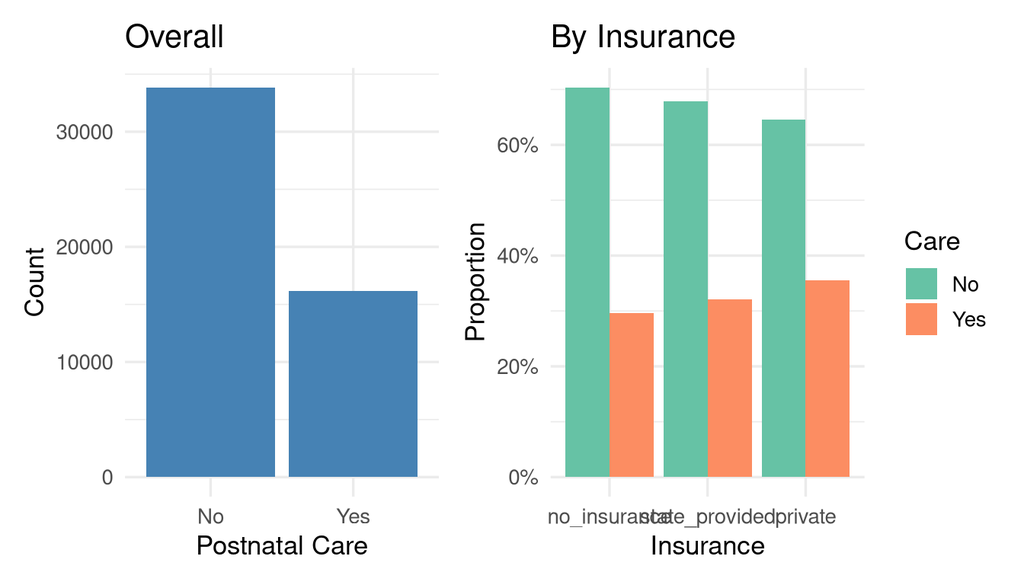

Figure 1: Postnatal care receipt rate overall and by insurance

```r
p1 <- ggplot(df, aes(x = postnatal_care)) +
  geom_bar(fill = "steelblue") +
  labs(x = "Postnatal Care", y = "Count", title = "Overall") +
  theme_minimal(base_size = 13)

p2 <- df |>
  count(insurance, postnatal_care) |>
  group_by(insurance) |>
  mutate(pct = n / sum(n)) |>
  ggplot(aes(x = insurance, y = pct, fill = postnatal_care)) +
  geom_col(position = "dodge") +
  scale_y_continuous(labels = percent_format()) +
  scale_fill_brewer(palette = "Set2", name = "Care") +
  labs(x = "Insurance", y = "Proportion", title = "By Insurance") +
  theme_minimal(base_size = 13)

p1 + p2
```

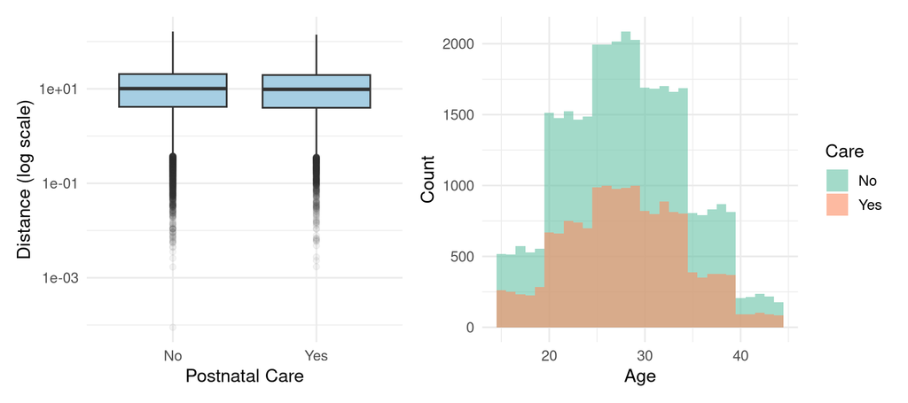

Figure 2: Distributions of distance to provider and age by postnatal care receipt

```r
p3 <- ggplot(df, aes(x = postnatal_care, y = distance_to_provider)) +
  geom_boxplot(fill = "#a6cee3", outlier.alpha = 0.05) +
  scale_y_log10() +
  labs(x = "Postnatal Care", y = "Distance (log scale)") +
  theme_minimal(base_size = 13)

p4 <- ggplot(df, aes(x = age, fill = postnatal_care)) +
  geom_histogram(bins = 30, alpha = 0.6, position = "identity") +
  scale_fill_brewer(palette = "Set2", name = "Care") +
  labs(x = "Age", y = "Count") +
  theme_minimal(base_size = 13)

p3 + p4
```

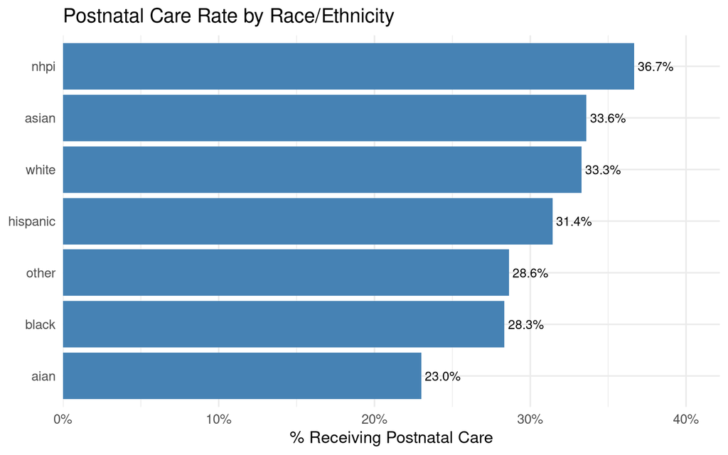

Figure 3: Postnatal care receipt by race/ethnicity

```r
df |>
  count(race_ethnicity, postnatal_care) |>
  group_by(race_ethnicity) |>
  mutate(pct = n / sum(n)) |>
  filter(postnatal_care == "Yes") |>
  ggplot(aes(x = reorder(race_ethnicity, pct), y = pct)) +
  geom_col(fill = "steelblue") +
  geom_text(aes(label = percent(pct, accuracy = 0.1)), hjust = -0.1, size = 3.5) +
  scale_y_continuous(labels = percent_format(), limits = c(0, NA), expand = expansion(mult = c(0, 0.15))) +
  coord_flip() +
  labs(x = NULL, y = "% Receiving Postnatal Care",
       title = "Postnatal Care Rate by Race/Ethnicity") +
  theme_minimal(base_size = 13)
```

### Modeling Strategy

The primary outcome — `received_comprehensive_postnatal_care` — is binary (0/1). This calls for **logistic regression**, the standard approach for binary outcomes. Logistic regression models the log-odds of the outcome as a linear function of predictors and produces odds ratios that are straightforward to interpret.

We include demographic, socioeconomic, access, and comorbidity predictors. We also create a composite `comorbidity_count` variable (sum of the 8 binary indicators) as a parsimonious way to capture overall health burden.

```r
df <- df |>
  mutate(
    comorbidity_count = obesity + multiple_gestation + diabetes + heart_disease +
      placenta_previa + hypertension + gest_hypertension + preeclampsia
  )
```

#### Fit the Logistic Regression

```r
fit <- glm(
  received_comprehensive_postnatal_care ~ age + self_report_income + edu +
    race_ethnicity + insurance + job_type + dependents +
    distance_to_provider + comorbidity_count,
  data = df,
  family = binomial(link = "logit")
)

summary(fit)
```

```
Call:
glm(formula = received_comprehensive_postnatal_care ~ age + self_report_income +
    edu + race_ethnicity + insurance + job_type + dependents +
    distance_to_provider + comorbidity_count, family = binomial(link = "logit"),
    data = df)

Coefficients:
                          Estimate Std. Error z value Pr(>|z|)
(Intercept)             -1.0301391  0.1372365  -7.506 6.08e-14 ***
age                     -0.0031122  0.0016362  -1.902 0.057169 .
self_report_income.L     0.2751880  0.1669082   1.649 0.099201 .
self_report_income.Q    -0.2019793  0.1562372  -1.293 0.196089
self_report_income.C    -0.0254657  0.1370681  -0.186 0.852611
self_report_income^4    -0.0362066  0.1178159  -0.307 0.758604
self_report_income^5     0.0194181  0.0958164   0.203 0.839401
self_report_income^6    -0.0433101  0.0710106  -0.610 0.541921
self_report_income^7    -0.0336327  0.0448208  -0.750 0.453025
edu.L                    0.0303574  0.0441117   0.688 0.491331
edu.Q                   -0.0175249  0.0363583  -0.482 0.629803
edu.C                   -0.0154162  0.0286263  -0.539 0.590209
edu^4                   -0.0046594  0.0212845  -0.219 0.826718
race_ethnicityasian      0.4997640  0.1271078   3.932 8.43e-05 ***
race_ethnicityblack      0.2669243  0.1245651   2.143 0.032125 *
race_ethnicityhispanic   0.4060315  0.1233160   3.293 0.000993 ***
race_ethnicitynhpi       0.6274721  0.2507112   2.503 0.012323 *
race_ethnicityother      0.2621642  0.1791215   1.464 0.143300
race_ethnicitywhite      0.4962666  0.1217277   4.077 4.56e-05 ***
insurancestate_provided  0.1198553  0.0258542   4.636 3.56e-06 ***
insuranceprivate         0.1916227  0.0251438   7.621 2.52e-14 ***
job_typetrade            0.0054597  0.0340719   0.160 0.872691
job_typeunemployed      -0.0659135  0.0579946  -1.137 0.255728
job_typeunskilled       -0.1598949  0.0290007  -5.513 3.52e-08 ***
dependents              -0.0176149  0.0120054  -1.467 0.142309
distance_to_provider    -0.0025391  0.0006684  -3.799 0.000146 ***
comorbidity_count        0.0356539  0.0096106   3.710 0.000207 ***
---
Signif. codes:  0 '***' 0.001 '**' 0.01 '*' 0.05 '.' 0.1 ' ' 1

(Dispersion parameter for binomial family taken to be 1)

    Null deviance: 62910  on 49999  degrees of freedom
Residual deviance: 62522  on 49973  degrees of freedom
AIC: 62576

Number of Fisher Scoring iterations: 4
```

#### Odds Ratios

```r
or_table <- tidy(fit, conf.int = TRUE, exponentiate = TRUE) |>
  filter(term != "(Intercept)") |>
  mutate(
    sig = case_when(
      p.value < 0.001 ~ "***",
      p.value < 0.01  ~ "**",
      p.value < 0.05  ~ "*",
      TRUE            ~ ""
    )
  ) |>
  select(Term = term, OR = estimate, `2.5%` = conf.low, `97.5%` = conf.high,
         p.value, sig)

or_table |>
  kable(digits = 3) |>
  kable_styling(bootstrap_options = "striped", full_width = FALSE)
```

| Term | OR | 2.5% | 97.5% | p.value | sig |
| --- | --- | --- | --- | --- | --- |
| age | 0.997 | 0.994 | 1.000 | 0.057 |  |
| self_report_income.L | 1.317 | 0.942 | 1.817 | 0.099 |  |
| self_report_income.Q | 0.817 | 0.596 | 1.104 | 0.196 |  |
| self_report_income.C | 0.975 | 0.741 | 1.271 | 0.853 |  |
| self_report_income^4 | 0.964 | 0.765 | 1.215 | 0.759 |  |
| self_report_income^5 | 1.020 | 0.846 | 1.232 | 0.839 |  |
| self_report_income^6 | 0.958 | 0.833 | 1.101 | 0.542 |  |
| self_report_income^7 | 0.967 | 0.886 | 1.056 | 0.453 |  |
| edu.L | 1.031 | 0.945 | 1.124 | 0.491 |  |
| edu.Q | 0.983 | 0.915 | 1.055 | 0.630 |  |
| edu.C | 0.985 | 0.931 | 1.042 | 0.590 |  |
| edu^4 | 0.995 | 0.955 | 1.038 | 0.827 |  |
| race_ethnicityasian | 1.648 | 1.290 | 2.125 | 0.000 | *** |
| race_ethnicityblack | 1.306 | 1.028 | 1.675 | 0.032 | * |
| race_ethnicityhispanic | 1.501 | 1.184 | 1.921 | 0.001 | *** |
| race_ethnicitynhpi | 1.873 | 1.138 | 3.050 | 0.012 | * |
| race_ethnicityother | 1.300 | 0.914 | 1.847 | 0.143 |  |
| race_ethnicitywhite | 1.643 | 1.300 | 2.096 | 0.000 | *** |
| insurancestate_provided | 1.127 | 1.072 | 1.186 | 0.000 | *** |
| insuranceprivate | 1.211 | 1.153 | 1.272 | 0.000 | *** |
| job_typetrade | 1.005 | 0.940 | 1.075 | 0.873 |  |
| job_typeunemployed | 0.936 | 0.835 | 1.049 | 0.256 |  |
| job_typeunskilled | 0.852 | 0.805 | 0.902 | 0.000 | *** |
| dependents | 0.983 | 0.960 | 1.006 | 0.142 |  |
| distance_to_provider | 0.997 | 0.996 | 0.999 | 0.000 | *** |
| comorbidity_count | 1.036 | 1.017 | 1.056 | 0.000 | *** |

#### Odds Ratio Plot

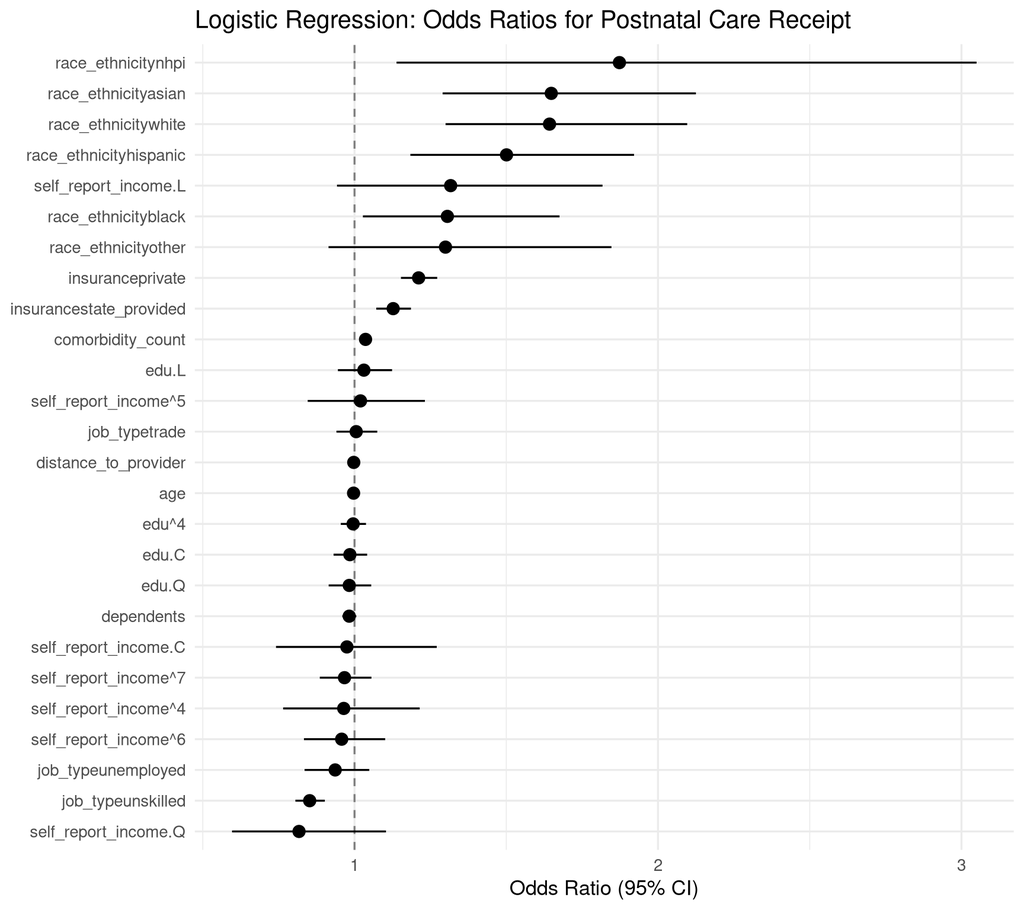

Figure 4: Odds ratios with 95% confidence intervals from logistic regression

```r
or_plot_data <- tidy(fit, conf.int = TRUE, exponentiate = TRUE) |>
  filter(term != "(Intercept)") |>
  mutate(term = reorder(term, estimate))

ggplot(or_plot_data, aes(x = estimate, y = term)) +
  geom_vline(xintercept = 1, linetype = "dashed", color = "grey50") +
  geom_pointrange(aes(xmin = conf.low, xmax = conf.high)) +
  labs(x = "Odds Ratio (95% CI)", y = NULL,
       title = "Logistic Regression: Odds Ratios for Postnatal Care Receipt") +
  theme_minimal(base_size = 13)
```

### Model Diagnostics

#### Goodness of Fit

```r
cat("Null deviance:    ", round(fit$null.deviance, 1),
    " on", fit$df.null, "df\n")
```

```
Null deviance:     62909.5  on 49999 df
```

```r
cat("Residual deviance:", round(fit$deviance, 1),
    " on", fit$df.residual, "df\n")
```

```
Residual deviance: 62522  on 49973 df
```

```r
cat("AIC:", round(AIC(fit), 1), "\n")
```

```
AIC: 62576
```

```r
# McFadden's pseudo-R²
null_ll <- logLik(update(fit, . ~ 1))
full_ll <- logLik(fit)
pseudo_r2 <- 1 - as.numeric(full_ll) / as.numeric(null_ll)
cat("McFadden pseudo-R²:", round(pseudo_r2, 4), "\n")
```

```
McFadden pseudo-R²: 0.0062
```

#### Residual Diagnostics

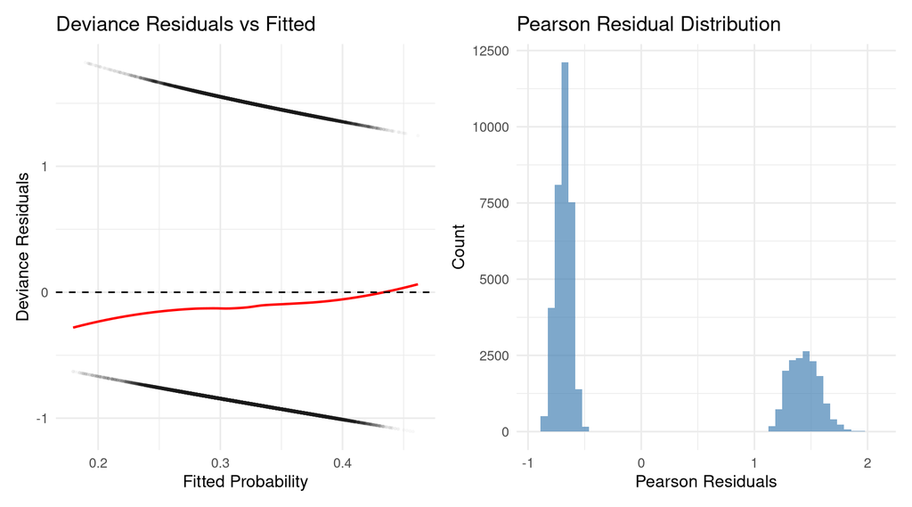

Figure 5: Residual diagnostics for logistic regression

```r
diag_df <- tibble(
  fitted_prob = fitted(fit),
  deviance_resid = residuals(fit, type = "deviance"),
  pearson_resid = residuals(fit, type = "pearson")
)

p_dev <- ggplot(diag_df, aes(x = fitted_prob, y = deviance_resid)) +
  geom_point(alpha = 0.02, size = 0.5) +
  geom_smooth(method = "loess", se = FALSE, color = "red", linewidth = 0.8) +
  geom_hline(yintercept = 0, linetype = "dashed") +
  labs(x = "Fitted Probability", y = "Deviance Residuals",
       title = "Deviance Residuals vs Fitted") +
  theme_minimal(base_size = 12)

p_hist <- ggplot(diag_df, aes(x = pearson_resid)) +
  geom_histogram(bins = 50, fill = "steelblue", alpha = 0.7) +
  labs(x = "Pearson Residuals", y = "Count",
       title = "Pearson Residual Distribution") +
  theme_minimal(base_size = 12)

p_dev + p_hist
```

#### Binned Residual Plot

A more informative diagnostic for binary outcomes — average residuals within bins of fitted values should hover near zero.

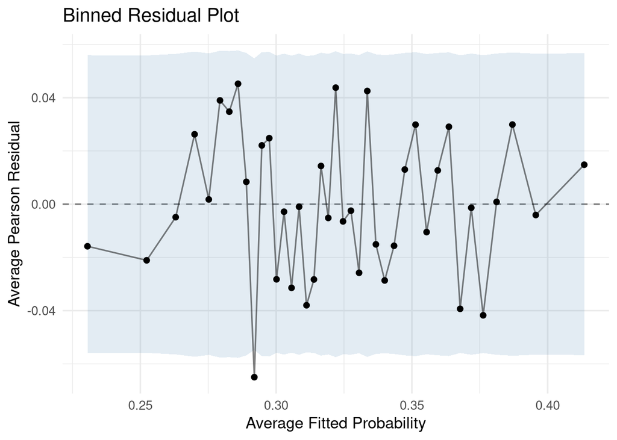

Figure 6: Binned residual plot: average residuals within bins of fitted probabilities

```r
n_bins <- 40
binned <- diag_df |>
  mutate(bin = ntile(fitted_prob, n_bins)) |>
  group_by(bin) |>
  summarise(
    avg_fitted = mean(fitted_prob),
    avg_resid = mean(pearson_resid),
    se = sd(pearson_resid) / sqrt(n()),
    .groups = "drop"
  )

ggplot(binned, aes(x = avg_fitted, y = avg_resid)) +
  geom_hline(yintercept = 0, linetype = "dashed", color = "grey50") +
  geom_ribbon(aes(ymin = -2 * se, ymax = 2 * se), alpha = 0.15, fill = "steelblue") +
  geom_point() +
  geom_line(alpha = 0.5) +
  labs(x = "Average Fitted Probability", y = "Average Pearson Residual",
       title = "Binned Residual Plot") +
  theme_minimal(base_size = 13)
```

### Interpretation and Caveats

**Limitations:**

1. **Observational data** — associations do not imply causation. Unmeasured confounders (health literacy, transportation access, provider quality) are likely present.
2. **Clustering** — patients are nested within providers and states. Standard errors may be underestimated. A multilevel model (e.g., `glmer()`) would be more appropriate but was not fit here for simplicity.
3. **Self-reported income** — subject to measurement error and reporting bias.
4. **Synthetic data** — this dataset is simulated. Findings reflect the data-generating process, not real-world patterns.
5. **No interaction terms** — the model assumes additive effects on the log-odds scale. Important interactions (e.g., race × insurance) were not explored.
6. **Multiple comparisons** — with many predictor levels, some nominally significant results may be spurious.